# 2025_28_11_McNair_2007

Stephanie Huang

2025-11-28

## PMF Table Clean up & Plotting of McNair 2007

Rat Peptide Mass Fingerprinting (2DIGE splot pick + MALDI - also LCMSMS for unresolved but not clear which were later ID’d by tandem ms).

- Adolescent/Young Adult Hooded Lister Male Rats (8 weeks) in an overnight playpen style EE paradigm for 6 weeks.
- Split Hippocampus CA1Somatic & Dendritic Fractions
  - Mostly Somatic Fraction is the stratum pyramidale
  - Dendritic Fraction is the stratum radiatum

*in Neuroscience - “*Global changes in the hippocampal proteome following exposure to an enriched environment*” https://doi.org/10.1016/j.neuroscience.2006.12.033*

Analysis originally done in R_WD > Proteomics > EE_TMT > v3_branched on 2025_11_28

Previous title 2025_28_11_McNair_2007_proteomics_data_PMF.Rmd

*NOTE TO SELF - TO DO - find gi acccession conversions to get gene ids* | + add names for class abbreviations.

### Load Packages

```r
library(readr)
library(readxl)
library(tidyr)
library(dplyr)
```

```r
library(stringr)
library(ggplot2)
library(gt) # gt tables
library(webr) # for piedonut
library(cowplot)
```

### Load Tables

```r
raw_som <- read_excel("input/McNair_2007_proteomics_table_raw.xlsx",
                      sheet = "1_somatic_fraction_raw")

raw_den <- read_excel("input/McNair_2007_proteomics_table_raw.xlsx",
                      sheet = "2_dendritic_fraction_raw")
```

## Clean up tables

### Bind both tables

```r
# make combined raw file with both fractions
com_raw <- bind_rows(list(Somatic = raw_som, Dendritic = raw_den),
                     .id = "Fraction")
```

```r
colnames(com_raw)
```

```
##  [1] "Fraction"                      "Spot no."
##  [3] "Master no."                    "Protein ID"
##  [5] "Av. Ratio"                     "Control vs. enriched (t-test)"
##  [7] "Mass"                          "NCBI Acc no."
##  [9] "Mowse Score"                   "Class"
```

### Remove rows with empty protein IDs & rows with now Mowse Score/NCBI Accession No. etc

NOTE TO SELF - look into this further! Pretty sure these are the missing unidenfitified spots but not 100% sure - double check

1. Remove anything with no protein ID or NCBI ID or Mowse score (so spots observed but no protein match?)
2. Due to 1 spot having multiple proteins (sometimes) use tidyr fill function to fill with value above.
   1. This done by 1st filling by spot number https://tidyr.tidyverse.org/reference/fill.html
3. Next, group by spot number & use fill on fold change & p value & fill with “downup”
   1. e.g. whatever present value in that group use to fill.
   2. This is probably a bit extra, but it is the safer option in case there are some weird rows.

```r
com_fil <- com_raw %>%
  filter(!is.na(`Protein ID`)) %>%   # goes from 132 obs to 108 obs
  filter(!is.na(`Mowse Score`)) %>%   # incl class & NCBI cols| now 105 obs
  fill(`Spot no.`, .direction = "down") %>%
  group_by(`Spot no.`) %>%
  fill(c(`Av. Ratio`,`Control vs. enriched (t-test)`),
       .direction = "downup")

# write out? or combine with below into 1?
```

### Fix weird dash, convert to numeric, & add direction of fold change column.

- weird dash - print w tail() to get observation
  - weird dash is − while normal one is (hyphen) -
  - once replaced with -, should let you convert to numeric & properly recognize & then make direction column as >0 = Up
  - https://stringr.tidyverse.org/reference/str_replace.html

```r
# fix weird dashes & make numeric + add direction col
# tail(com_fil)

com_df <- com_fil %>%
  # NEW CODE | keep old col just to be safe
  mutate(avg_ratio = str_replace(`Av. Ratio`, "−", "-"),  #old,new
         .after = `Av. Ratio`) %>%
  mutate(avg_ratio = round(as.numeric(avg_ratio),2)) %>%
  mutate(Direction = ifelse(avg_ratio > 0, "Up", "Down"),
         .after = "avg_ratio")
```

#### Write out data frame

```r
#write_csv(com_df, "output/2025_28_11_McNair2007_data_cleaned_v1.csv")
```

## Plots

### Barplots

- geom_bar vs geom_col - https://r-charts.com/ranking/bar-plot-ggplot2/
  - geom_bar counts occurences! Then: position = position_dodge(preserve = ‘single’, width=1) - keeps width for bars the same!
  - polar coordinates pie bar - looks cool but not the right one - https://stackoverflow.com/questions/59922719/pie-chart-with-ggplot2-counting-the-occurrences-of-entries

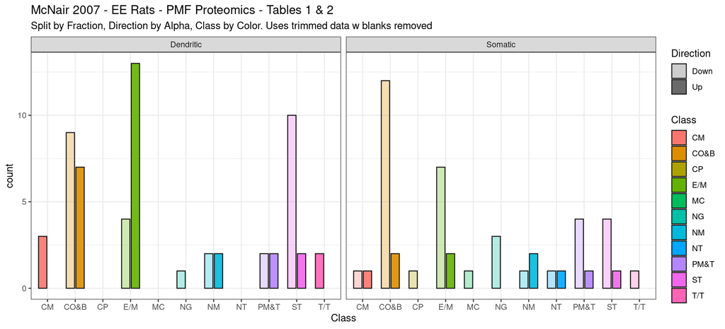

```r
barplots_1 <- ggplot(com_df,
                 aes(x = Class, fill = Class, alpha = Direction)) +
  geom_bar(position = position_dodge(preserve = 'single', width=0.7),
           width = 0.6, color = "grey10") +
  #coord_polar(theta='y') + # spiral! not the right one but cool looking
  facet_wrap(~ Fraction, ncol = 2) +
  scale_alpha_discrete(range = c(0.3, 0.9)) +
  labs(title = "McNair 2007 - EE Rats - PMF Proteomics - Tables 1 & 2",
      subtitle = "Split by Fraction, Direction by Alpha, Class by Color. Uses trimmed data w blanks removed") +
  theme_bw()
barplots_1
```

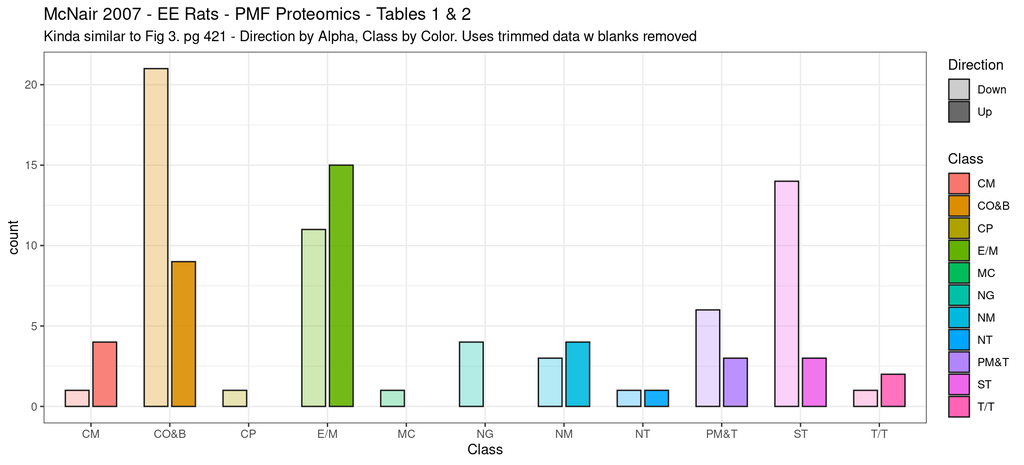

```r
barplots_2 <- ggplot(com_df,
                 aes(x = Class, fill = Class, alpha = Direction)) +
  geom_bar(position = position_dodge(preserve = 'single', width=0.7),
           width = 0.6, color = "grey10") +
  #coord_polar(theta='y') + # spiral! not the right one but cool looking
  scale_alpha_discrete(range = c(0.3, 0.9)) +
  labs(title = "McNair 2007 - EE Rats - PMF Proteomics - Tables 1 & 2",
      subtitle = "Kinda similar to Fig 3. pg 421 - Direction by Alpha, Class by Color. Uses trimmed data w blanks removed") +
  theme_bw()
barplots_2
```

```r
# by group!
summed_df <- com_df %>%
  group_by(Fraction) %>%
  count(Class) %>%
  mutate(Percentage = round(n/sum(n) * 100,0))
```

### Base R Pie Charts

```r
print(summed_df) # 1- dendritc & 9-19 somatic
```

```
## # A tibble: 19 × 4
## # Groups:   Fraction [2]
##    Fraction  Class     n Percentage
##    <chr>     <chr> <int>      <dbl>
##  1 Dendritic CM        3          5
##  2 Dendritic CO&B     16         27
##  3 Dendritic E/M      17         29
##  4 Dendritic NG        1          2
##  5 Dendritic NM        4          7
##  6 Dendritic PM&T      4          7
##  7 Dendritic ST       12         20
##  8 Dendritic T/T       2          3
##  9 Somatic   CM        2          4
## 10 Somatic   CO&B     14         30
## 11 Somatic   CP        1          2
## 12 Somatic   E/M       9         20
## 13 Somatic   MC        1          2
## 14 Somatic   NG        3          7
## 15 Somatic   NM        3          7
## 16 Somatic   NT        2          4
## 17 Somatic   PM&T      5         11
## 18 Somatic   ST        5         11
## 19 Somatic   T/T       1          2
```

```r
names <- summed_df$Class # make names list from col
```

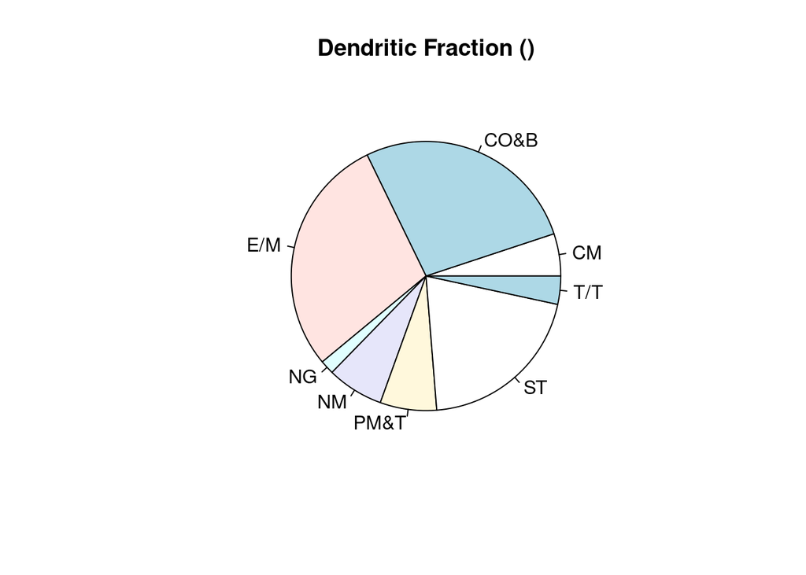

```r
pie(summed_df$n[1:8], labels = names[1:8],
    main = "Dendritic Fraction ()") # dendritic
```

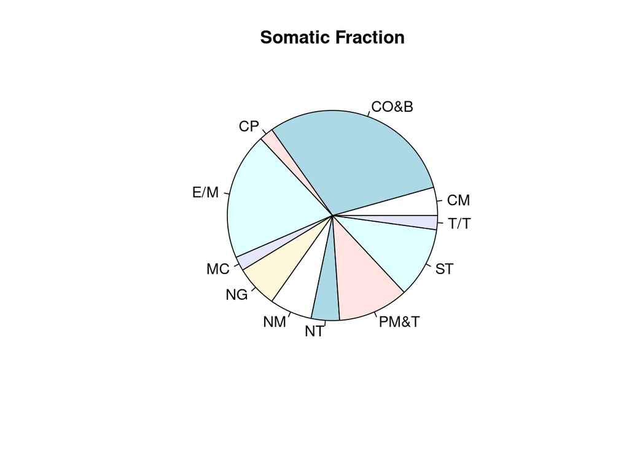

```r
pie(summed_df$n[9:19], labels = names[9:19],
    main = "Somatic Fraction") # somatic
```

### ggplot pie charts

- https://r-graph-gallery.com/piechart-ggplot2.html

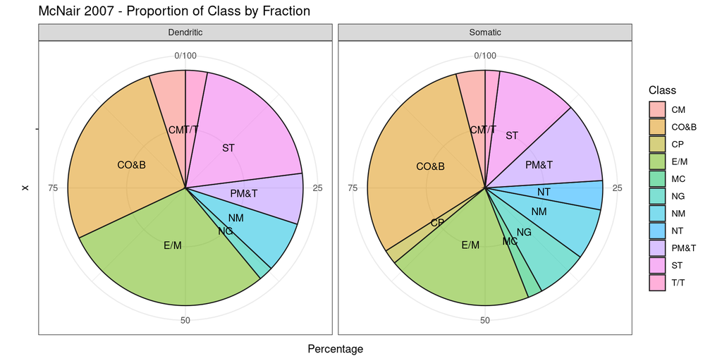

```r
ggpie <- ggplot(summed_df,
                aes(x = "", y=Percentage, fill = Class)) +
  geom_bar(stat="identity", width = 1,
           color = "grey10", alpha = 0.5) +
  coord_polar("y", start = 0) +
  geom_text(aes(label = Class), position = position_stack(vjust = .5),
            size = 3.5) +
  facet_wrap(~Fraction) +
  labs(title = "McNair 2007 - Proportion of Class by Fraction") +
  theme_bw()

ggpie
```

#### piedonut

- https://cardiomoon.github.io/webr/articles/PieDonut.html

```r
PieDo_den <- com_df %>%
  filter(Fraction == "Dendritic") %>%
  PieDonut(aes(pie = Class, donut = Direction),
         pieLabelSize = 3, donutLabelSize = 2.5,
         showPieName = FALSE)
```

[figure not shown]

```r
PieDo_som <- com_df %>%
  filter(Fraction == "Somatic") %>%
  PieDonut(aes(pie = Class, donut = Direction),
         pieLabelSize = 3, donutLabelSize = 2.5,
         showPieName = FALSE)
```

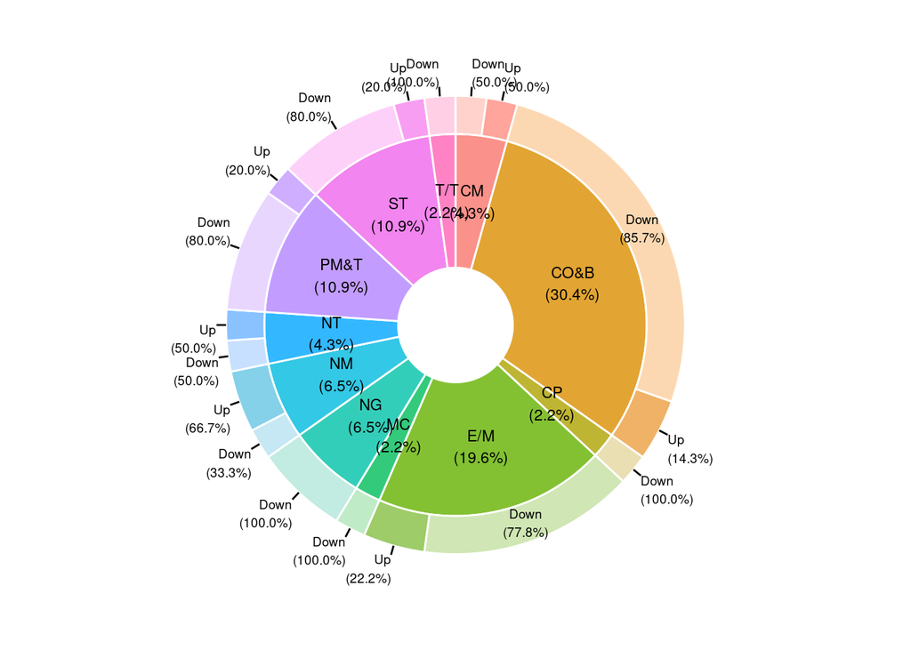

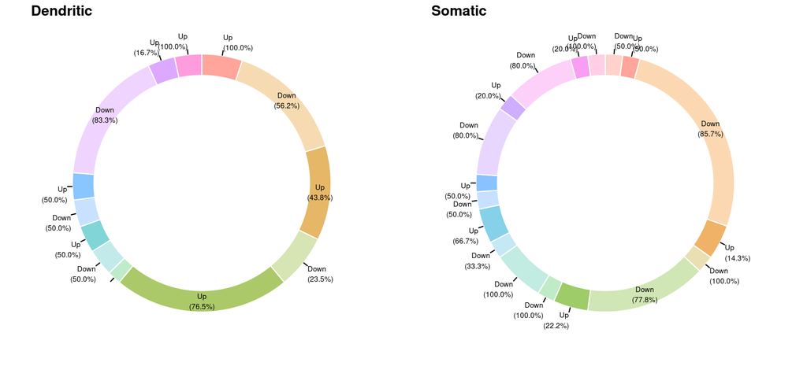

```r
# why does it look like this?!?!?! :(
plot_grid(PieDo_den, PieDo_som,
          labels = c('Dendritic', 'Somatic'))
```

## Cleaned up gt table

- https://gt.rstudio.com/

```r
# gt 1 - by fold change direction & pvalue
com_df |>
  dplyr::select(-(c(`Av. Ratio`, ))) |>
  dplyr::arrange(`Control vs. enriched (t-test)`) |>
  gt(
    groupname_col = "Direction"
  ) |>
    tab_header(
      title = "McNair 2007 - Tables 1 & 2",
      subtitle = "Cleaned data, Organised by Fold Change Direction & Arranged by pvalue"
    ) |>
    tab_options(table.font.size=12)
```

McNair 2007 - Tables 1 & 2

Cleaned data, Organised by Fold Change Direction & Arranged by pvalue

| Fraction | Spot no. | Master no. | Protein ID | avg_ratio | Control vs. enriched (t-test) | Mass | NCBI Acc no. | Mowse Score | Class |
| --- | --- | --- | --- | --- | --- | --- | --- | --- | --- |
| Up |  |  |  |  |  |  |  |  |  |
| Somatic | 7 | 491 | Dynamin 1 | 1.18 | 0.00048 | 96209 | gi 18093102 | 215 | CO&B |
| Dendritic | 44 | 2080 | Phosphoglycerate mutase B | 1.48 | 0.00083 | 28942 | gi 8248819 | 98 | E/M |
| Dendritic | 44 | NA | Hsc 70-psI | 1.48 | 0.00083 | 71112 | gi 56385 | 402 | CO&B |
| Dendritic | 44 | NA | Rho-associated coiled-coil forming kinase 2 | 1.48 | 0.00083 | 160475 | gi 6981478 | 31 | ST |
| Somatic | 8 | 1395 | 4-Aminobutyrate transaminase | 1.16 | 0.00550 | 57178 | gi 2143559 | 66 | NT |
| Dendritic | 43 | 2030 | ATP synthase α (M) | 2.98 | 0.00580 | 58904 | gi 114523 | 293 | NM |
| Dendritic | 43 | NA | VAMP-associated protein A | 2.98 | 0.00580 | 27476 | gi 61889097 | 59 | ST |
| Dendritic | 43 | NA | Glyceraldehyde 3-phosphate-dehydrogenase | 2.98 | 0.00580 | 36098 | gi 56188 | 320 | E/M |
| Somatic | 4 | 1584 | Citrate synthase | 1.26 | 0.00630 | 52176 | gi 18543177 | 174 | E/M |
| Somatic | 4 | NA | Phosphoglycerate kinase 1 | 1.26 | 0.00630 | 44909 | gi 40254752 | 111 | CM |
| Dendritic | 46 | 2078 | Pgam1 protein | 1.41 | 0.00960 | 28928 | gi 12805529 | 225 | CM |
| Dendritic | 46 | NA | Proteasome 26S non-ATPase subunit 9 | 1.41 | 0.00960 | 24985 | gi 18426862 | 121 | PM&T |
| Dendritic | 52 | 1289 | Aldehyde dehydrogenase 7, A1 | 1.21 | 0.00970 | 25313 | gi 25090044 | 49 | E/M |
| Dendritic | 48 | 1579 | Pyruvate dehydrogenase E1 α | 1.27 | 0.01400 | 43853 | gi 57657 | 781 | E/M |
| Dendritic | 48 | NA | Phosphoglycerate kinase 1 | 1.27 | 0.01400 | 44909 | gi 40254752 | 281 | E/M |
| Dendritic | 48 | NA | SEC14-like protein 2 | 1.27 | 0.01400 | 46593 | gi 21542226 | 158 | T/T |
| Dendritic | 48 | NA | Citrate synthase | 1.27 | 0.01400 | 52176 | gi 18543177 | 104 | E/M |
| Dendritic | 48 | NA | RNA binding protein p42 AUF1 | 1.27 | 0.01400 | 36164 | gi 9588098 | 72 | T/T |
| Dendritic | 53 | 1967 | Actin, β | 1.21 | 0.01900 | 42066 | gi 71620 | 260 | CO&B |
| Dendritic | 53 | NA | Tubulin, β | 1.21 | 0.01900 | 50095 | gi 27465535 | 39 | CO&B |
| Somatic | 3 | 1312 | ATP synthase α (M) | 1.28 | 0.02100 | 58904 | gi 114523 | 95 | NM |
| Dendritic | 50 | 1288 | Heat shock protein 60 precursor | 1.25 | 0.02400 | 58061 | gi 1334284 | 87 | CO&B |
| Dendritic | 45 | 2075 | Pgam1 protein | 1.43 | 0.02500 | 28928 | gi 12805529 | 97 | CM |
| Dendritic | 45 | NA | Chain F, Enoyl-Coa hydratase complexed with octanoyl-Coa | 1.43 | 0.02500 | 28555 | gi 3212683 | 145 | E/M |
| Dendritic | 54 | 1844 | Malate dehydrogenase (M) | 1.18 | 0.02700 | 36117 | gi 42476181 | 112 | E/M |
| Somatic | 11 | 2232 | Proteasome subunit, β type 2 | 1.12 | 0.03300 | 23069 | gi 8394079 | 272 | PM&T |
| Somatic | 11 | NA | Auh protein | 1.12 | 0.03300 | 33605 | gi 34873875 | 132 | E/M |
| Somatic | 11 | NA | ATP synthase α (M) | 1.12 | 0.03300 | 58904 | gi 114523 | 82 | NM |
| Somatic | 11 | NA | RAB7 | 1.12 | 0.03300 | 23075 | gi 92022 | 39 | ST |

[output cut: 77 more lines]